# HT terminators

Claire Rioualen

2021-11-29

```r
library(ggplot2)
library(dplyr)
library(DT)
library(gridExtra)
library(readxl)
library(tidyr)

## Pending proper installation
devtools::load_all("~/Desktop/Git/EcoliGenes")

concat_uniq <- function(x, sep = ","){
  paste0(unique(na.omit(x)), collapse = sep)
}

check_dup <- function(df){
  test_dup <- df %>%
    mutate(coords = paste0(start, "_", stop, "_", strand)) %>%
    group_by(coords) %>%
    summarise(count = n(),
              across(where(is.character), concat_uniq, sep = "_"),
              across(where(is.numeric), concat_uniq, sep = "_"),
              .groups = 'drop') %>%
    arrange(desc(count)) %>%
    filter(count>1)
  test_dup
}

## wrapper function to remove commented rows from excel sheets
read_excel_cm <- function(file, sheet, comment.char = "#"){
  tab <- read_excel(file, sheet, col_names = F)
  skip_rows <- grep(paste0("^", comment.char), unlist(c(tab[,1])))
  if(length(skip_rows) > 0) tab <- read_excel(file, sheet, skip = max(skip_rows))
  return(tab)
}
```

# Transcription terminators

## Format

Here, a **dataset** is defined by a combination of **PMID and experimental condition**.

TTSs are collected from a variety of sources and processed to produce uniform bed-like dataset files with the following fields:

- **chromosome:** NC_000913.3
- **start:** Left genomic position. If not reported, will be the same as `term_pos`
- **stop:** Right genomic position. If not reported, will be the same as `term_pos`
- **id:** Unique TSS ID
- **term_pos:** Terminal position reported by authors
- **strand:** TTS strand reported by authors

## Metadata

```r
metadata_file <- "DatasetCollection-Terminators-HT_v0.3.xlsx"
```

- Metadata file version used: **DatasetCollection-Terminators-HT_v0.3.xlsx**

```r
## Read metadata table, filter out datasets that don't have a condition associated
ht_term_metadata <- read_excel_cm(paste0(ht_collection_dir, "/coleccion_TTS/metadata/", metadata_file), sheet = "TTS_v0.2") %>%
  dplyr::rename(dataset_id = "Dataset ID",
                pmid = "PMID",
                author = "Authors",
                condition = "Growth Conditions Experimental",
                file = "Dataset File Name") %>%
  dplyr::select(dataset_id, pmid, author, condition) %>%
  dplyr::filter(!is.na(condition))

## Make dataset list from table
ht_term_dataset_list <- setNames(split(ht_term_metadata, seq(nrow(ht_term_metadata))), ht_term_metadata$dataset_id)
```

```r
## Display datasets
DT1 <- DT::datatable(ht_term_metadata, options = list(dom = '', pageLength = 20, autoWidth = TRUE, columnDefs = list(list(width = '200px', targets = c(3, 4)))))
DT1
```

|  | dataset_id | pmid | author | condition |
| --- | --- | --- | --- | --- |
| 1 | TR0001 | 31308523 | Ju, X., D. Li and S. Liu | ORGANISM:Escherichia coli \|MEDIUM:LB medium \|GROWTH_PHASE:Exponential phase |
| 2 | TR0002 | 31308523 | Ju, X., D. Li and S. Liu | ORGANISM:Escherichia coli \|MEDIUM:LB medium \|GROWTH_PHASE:Stationary phase |
| 3 | TR0003 | 25006232 | Conway, T., J. P. Creecy, S. M. Maddox, J. E. Grissom, T. L. Conkle, T. M. Shadid, J. Teramoto, P. San Miguel, T. Shimada, A. Ishihama, H. Mori and B. L. Wanner | ORGANISM:Escherichia coli BW38028 \|MEDIUM:MOPS \|OPTICAL_DENSITY:OD600 of 0.4 \|GROWTH_PHASE:Exponential phase |
| 4 | TR0004 | 30201986 | Yan, B., M. Boitano, T. A. Clark and L. Ettwiller | ORGANISM:Escherichia coli str. K-12 substr. MG1655 \|GENETIC_BACKGROUND:wild type \|MEDIUM:M9 minimal medium \|GROWTH_PHASE:Exponential phase |
| 5 | TR0005 | 30201986 | Yan, B., M. Boitano, T. A. Clark and L. Ettwiller | ORGANISM:Escherichia coli str. K-12 substr. MG1655 \|GENETIC_BACKGROUND:wild type \|MEDIUM:rich medium \|GROWTH_PHASE:Exponential phase |

## Datasets per author

This part is customized depending on the originally published files. Since those files are formatted each in their own way, this part is partly manual and should be modified carefully.

### Conway

Reference article: [Conway et al., 2014](https://doi.org/10.1128/mbio.01442-14)

Conditions:

- Exponential phase

Notes:

- Genome coordinates were converted from version U00096.2 to version U00096.3 [here](https://biocyc.org/ECOLI/map-seq-coords-form?chromosome=COLI-K12)

```r
## Code executed just once, in order to export promoters coordinates and convert them through Ecocyc
##---------------------------------------------------------------------------------
# file <- "inline-supplementary-material-6 (terminators).xlsx"
# read_excel(paste0(ht_collection_dir, "/coleccion_TTS/author_files/", file), skip = 1) %>%
#   dplyr::mutate(term_pos = as.numeric(gsub("^[A-Z]{1,2}-{1}", "", Term)), strand = Strand) %>%
#   dplyr::select(term_pos, strand) %>%
#   write.table(file = paste0(ht_collection_dir, "/coleccion_TTS/author_files/intermediate_files/Conway_TTS_parsed.tsv"), sep = "\t", quote = F, col.names = T, row.names = F)

## Conversion Conway_TTS_parsed.tsv -> Conway_TTS_parsed_converted.tsv

TR0003 <- read.delim(paste0(ht_collection_dir, "/coleccion_TTS/author_files/intermediate_files/Conway_TTS_parsed_converted.tsv"), comment.char = "#", header = T) %>%
  dplyr::distinct()
```

### Ju

Reference article: [Ju et al., 2019](https://doi.org/10.1038/s41564-019-0500-z)

Conditions:

- exponential phase
- stationary phase

```r
##---------------------------------------------------------------------------------
file <- "Ju et al_Supplementary Table 2.xlsx"
TR0001_TR0002 <- read_excel(paste0(ht_collection_dir, "/coleccion_TTS/author_files/source_files/", file), skip = 2) %>%
  dplyr::rename(term_pos = TTS_position,
                strand = TTS_strand) %>%
  dplyr::distinct()

##---------------------------------------------------------------------------------
TR0001 <- TR0001_TR0002 %>%
  dplyr::filter(!is.na(log_TTS)) %>%
  dplyr::select(strand, term_pos)

TR0002 <- TR0001_TR0002 %>%
  dplyr::filter(!is.na(stationary_TTS)) %>%
  dplyr::select(strand, term_pos)
```

### Yan

Reference article: Yan et al., 2018

Conditions:

- M9 (minimal growth medium)
- Rich (rich growth medium)

Notes:

- Two types of TU termination are reported for each condition: detected TTS or longest read end. The latter was not included.

```r
##---------------------------------------------------------------------------------
TR0004 <- read.table(paste0(ht_collection_dir, "/coleccion_TUs/author_files/source_files/M9_RegulonDB_TU_definedEnd.txt"), stringsAsFactors = F) %>%
  dplyr::rename(start = V1, stop = V2, strand = V3) %>%
  dplyr::mutate(term_pos = ifelse(strand == "-", start, stop)) %>%
  dplyr::select(strand, term_pos) %>%
  dplyr::distinct()


##---------------------------------------------------------------------------------
TR0005 <- read.table(paste0(ht_collection_dir, "/coleccion_TUs/author_files/source_files/Rich_RegulonDB_TU_definedEnd.txt"), stringsAsFactors = F) %>%
  dplyr::rename(start = V1, stop = V2, strand = V3) %>%
  dplyr::mutate(term_pos = ifelse(strand == "-", start, stop)) %>%
  dplyr::select(strand, term_pos) %>%
  dplyr::distinct()
```

## Uniformization

This part assumes that the specificities of each individual dataset were dealt with previously. It generates unique IDs for terminators and writes one file per dataset.

```r
term_dir <- paste0(ht_collection_dir, "/coleccion_TTS/uniformized_data")
datasets_list <- list()

## Process all datasets automatically
for(ds_id in names(ht_term_dataset_list)) {
  df <- get(ds_id) %>%
    dplyr::mutate(id = paste0("TTS_", ds_id, "_", dplyr::row_number()),
                  start = term_pos,
                  stop = term_pos,
                  chromosome = "NC_000913.3") %>%
    dplyr::arrange(start)


  write.table(df %>% dplyr::select(chromosome, start, stop, id, term_pos, strand), file = paste0(term_dir, "/", ds_id, ".tsv"), sep = "\t", quote = F, col.names = T, row.names = F)

  assign(ds_id, df)

  datasets_list[[ds_id]] <- df

}
```

- Write a summary file for TU datasets

```r
ht_term_stats <- ht_term_metadata %>%
  dplyr::rowwise() %>%
  dplyr::mutate(term_number = nrow(get(dataset_id))) %>%
  dplyr::select(dataset_id, pmid, author, condition, term_number)

write.table(ht_term_stats, file = paste0(term_dir, "/TTS_datasets.tsv"), sep = "\t", quote = F, col.names = T, row.names = F)
```

## Results

### Summary of datasets

```r
DT2 <- DT::datatable(ht_term_stats, options = list(dom = '', pageLength = 20)) %>% DT::formatRound('term_number', digits=0)
DT2
```

|  | dataset_id | pmid | author | condition | term_number |
| --- | --- | --- | --- | --- | --- |
| 1 | TR0001 | 31308523 | Ju, X., D. Li and S. Liu | ORGANISM:Escherichia coli \|MEDIUM:LB medium \|GROWTH_PHASE:Exponential phase | 1473 |
| 2 | TR0002 | 31308523 | Ju, X., D. Li and S. Liu | ORGANISM:Escherichia coli \|MEDIUM:LB medium \|GROWTH_PHASE:Stationary phase | 1352 |
| 3 | TR0003 | 25006232 | Conway, T., J. P. Creecy, S. M. Maddox, J. E. Grissom, T. L. Conkle, T. M. Shadid, J. Teramoto, P. San Miguel, T. Shimada, A. Ishihama, H. Mori and B. L. Wanner | ORGANISM:Escherichia coli BW38028 \|MEDIUM:MOPS \|OPTICAL_DENSITY:OD600 of 0.4 \|GROWTH_PHASE:Exponential phase | 1774 |
| 4 | TR0004 | 30201986 | Yan, B., M. Boitano, T. A. Clark and L. Ettwiller | ORGANISM:Escherichia coli str. K-12 substr. MG1655 \|GENETIC_BACKGROUND:wild type \|MEDIUM:M9 minimal medium \|GROWTH_PHASE:Exponential phase | 352 |
| 5 | TR0005 | 30201986 | Yan, B., M. Boitano, T. A. Clark and L. Ettwiller | ORGANISM:Escherichia coli str. K-12 substr. MG1655 \|GENETIC_BACKGROUND:wild type \|MEDIUM:rich medium \|GROWTH_PHASE:Exponential phase | 375 |

```r
total_tts <- nrow(bind_rows(datasets_list))
```

Total objects: 5326

### Distributions

#### Number of terminators per dataset

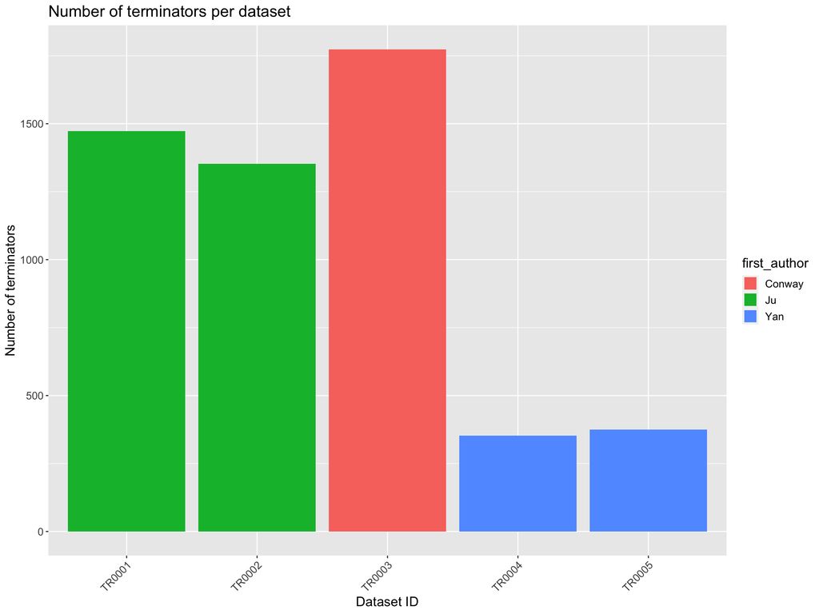

```r
ht_term_stats_legends <- ht_term_stats  %>%
  dplyr::mutate(first_author = str_split(author, ",")[[1]][1])

ggplot(ht_term_stats_legends, aes(x = dataset_id, y = term_number, fill = first_author)) +
  geom_col(size = 2) +
  # scale_fill_manual(values = RColorBrewer::brewer.pal(length(unique(ht_term_stats$author)), "Pastel2")) +
  theme(axis.text.x = element_text(angle = 45, hjust=1), text = element_text(size = 14)) +
  ylab("Number of terminators") +
  xlab("Dataset ID") +
  labs(title = "Number of terminators per dataset")
```